# Lab 01 - Getting To Common Ground

Imports first. We do these at the top so they don't get in the way of reading the rest - so we can concentrate on the work, and not programming boilerplate.

```python
import numpy as np
import matplotlib.pyplot as plt
```

For those of you that aren't aware of this nice `python` feature - the `as np` is a short cut so we can refer to `numpy.sin` as `np.sin` below.

## Generating the 1D Normal Distribution

```python
data = np.random.normal(0.0, scale=1.0, size=10000)
```

```python
data
```

[output not shown]

[output cut: 195 more lines]

[output not shown]

Lets make a histogram of it:

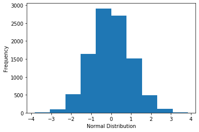

```python
plt.hist(data, bins=10)
plt.xlabel('Normal Distribution')
plt.ylabel('Frequency')
```

[figure not shown]

```python
plt.hist(data, bins=75)
plt.xlabel('Normal Distribution')
plt.ylabel('Frequency')
```

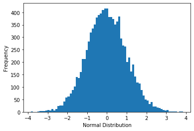

```python
plt.hist(data, bins=75)
plt.xlabel('Normal Distribution')
plt.ylabel('Frequency')
```

[figure not shown]

```python
plt.hist(data, bins=2)
plt.xlabel('Normal Distribution')
plt.ylabel('Frequency')
```

Obviously, there are too few here!

[figure not shown]

```python
plt.hist(data, bins=10)
plt.xlabel('Normal Distribution')
plt.ylabel('Frequency')
```

10 bins seems about correct!

## Exponential Distirbution

```python
data_exp = np.random.exponential(0.1, 10000)
```

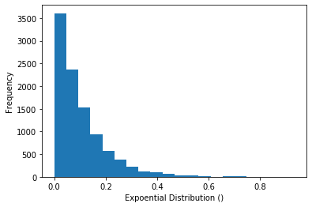

```python
plt.hist(data_exp, bins=20)
plt.xlabel('Expoential Distribution ()')
plt.ylabel('Frequency')
```

## Scatter Plot of the distributions

```python
data_2d = np.random.normal(0.0, 1.0, (2, 20000))
```

The first time I wrote the above line I had `(20000, 2)`, which gives an array with the dimensions inverted. By printing out `data_2d[0]` i was able to quickly see my mistake. Of course, I've not removed all evidence of my mistake and made my notebook nice and clean. This is pretty typical of most notebooks you see on the internet! One final thing - if you clean up, it is important to restart your kernel (see menu item under Kernel) and run everything from scratch incase you accidentally deleted something you need!

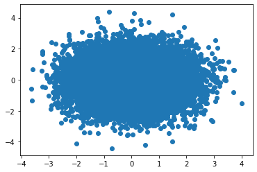

```python
plt.scatter(data_2d[0], data_2d[1])
```

Ok - that is actually a pretty useless plot. As many of you discovered from discussions in class - the scatter plot can really lie to you when it has lots of data. Instead, it is much better to use one of the other types of 2D plots. I saw you all using lots of different types. If I can't think up a plot on my own, I sometimes to look at examples (e.g. [MatPlotLib examples](https://matplotlib.org/gallery/index.html)).

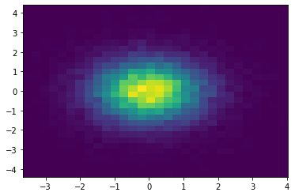

```python
_ = plt.hist2d(data_2d[0], data_2d[1], bins=(30,30))
```

The `_ =` is because `hist2d` returns an array of bin edges, and the notebook will dump that, getting in the way of what I want to show. So I put the result in the variable `_`. In python this usually means that we do not care about that value.